# Individual Final Submission TO 404

Tanisha Pardasani

```r
library(tidyverse)
```

```r
library(dplyr)
library(ggplot2)
library(lubridate)
# Reading in and cleaning the data
airbnb <- read.csv('AB_NYC_2019.csv', stringsAsFactors = TRUE)
airbnb$id <- NULL
airbnb$reviews_per_month <- ifelse(is.na(airbnb$reviews_per_month) == TRUE, 0,
                                   airbnb$reviews_per_month)

head(airbnb)
```

```
##                                               name host_id   host_name
## 1               Clean & quiet apt home by the park    2787        John
## 2                            Skylit Midtown Castle    2845    Jennifer
## 3              THE VILLAGE OF HARLEM....NEW YORK !    4632   Elisabeth
## 4                  Cozy Entire Floor of Brownstone    4869 LisaRoxanne
## 5 Entire Apt: Spacious Studio/Loft by central park    7192       Laura
## 6        Large Cozy 1 BR Apartment In Midtown East    7322       Chris
##   neighbourhood_group neighbourhood latitude longitude       room_type price
## 1            Brooklyn    Kensington 40.64749 -73.97237    Private room   149
## 2           Manhattan       Midtown 40.75362 -73.98377 Entire home/apt   225
## 3           Manhattan        Harlem 40.80902 -73.94190    Private room   150
## 4            Brooklyn  Clinton Hill 40.68514 -73.95976 Entire home/apt    89
## 5           Manhattan   East Harlem 40.79851 -73.94399 Entire home/apt    80
## 6           Manhattan   Murray Hill 40.74767 -73.97500 Entire home/apt   200
##   minimum_nights number_of_reviews last_review reviews_per_month
## 1              1                 9  2018-10-19              0.21
## 2              1                45  2019-05-21              0.38
## 3              3                 0                          0.00
## 4              1               270  2019-07-05              4.64
## 5             10                 9  2018-11-19              0.10
## 6              3                74  2019-06-22              0.59
##   calculated_host_listings_count availability_365
## 1                              6              365
## 2                              2              355
## 3                              1              365
## 4                              1              194
## 5                              1                0
## 6                              1              129
```

We are looking at the Manhattan neighborhood only.

```r
#restrict neigbourhood group to Manhattan
manhattan <-
    airbnb %>%
    group_by (name) %>%
    filter (neighbourhood_group == "Manhattan")
head(manhattan)
```

```
## # A tibble: 6 x 15
## # Groups:   name [6]
##   name  host_id host_name neighbourhood_g… neighbourhood latitude longitude
##   <fct>   <int> <fct>     <fct>            <fct>            <dbl>     <dbl>
## 1 "Sky…    2845 Jennifer  Manhattan        Midtown           40.8     -74.0
## 2 "THE…    4632 Elisabeth Manhattan        Harlem            40.8     -73.9
## 3 "Ent…    7192 Laura     Manhattan        East Harlem       40.8     -73.9
## 4 "Lar…    7322 Chris     Manhattan        Murray Hill       40.7     -74.0
## 5 "Lar…    8967 Shunichi  Manhattan        Hell's Kitch…     40.8     -74.0
## 6 "Coz…    7490 MaryEllen Manhattan        Upper West S…     40.8     -74.0
## # … with 8 more variables: room_type <fct>, price <int>, minimum_nights <int>,
## #   number_of_reviews <int>, last_review <fct>, reviews_per_month <dbl>,
## #   calculated_host_listings_count <int>, availability_365 <int>
```

## Does the number of reviews on AirBnb rentals in Manhattan have an effect on the price?

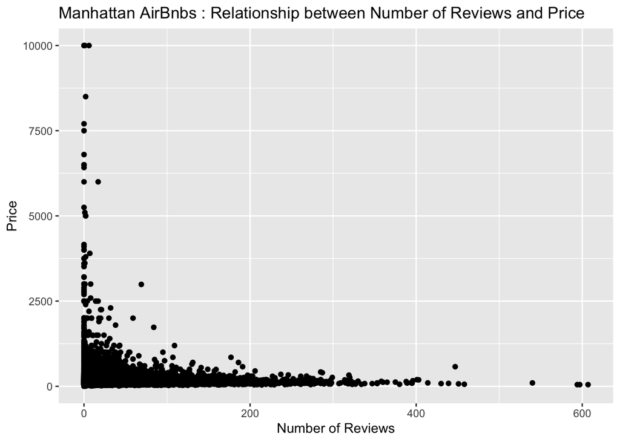

```r
  ggplot(manhattan, aes (x=number_of_reviews, y = price)) + geom_point() +
  xlab ("Number of Reviews") + ylab ("Price") + ggtitle("Manhattan AirBnbs : Relationship between Number of Reviews and Price")
```

Looking at the plot, it appears that the number of reviews and price of AirBnb rentals in Manhattan are negatively correlated. In other words the plot shows that AirBnbs with more reviews tend to be cheaper than those with less. The most expensive AirBnbs are the most expensive.

If an AirBnb has many reviews, there is bound to be at least some negative reviews. On the other hand, if an AirBnb has very few reviews it is likely that they could all be positive, giving the potential customer a skewed view of the quality of the rental. A customer is probably likely to choose a rental with few relatively positive reviews over a rental with many mixed reviews. Therefore, the rentals with fewer reviews are likely more popular and more in demand than rentals with many reviews. Due to this, it makes sense that the prices for rentals with high amounts of reviews tend to be cheaper because of lower demand and more negative reviews.

## What is the average number of reviews and average price of Manhattan AirBnbs?

## What is the average price of rentals that have above and below the mean number of reviews?

```r
avg_number_of_reviews <- ( mean ( manhattan$number_of_reviews))
avg_number_of_reviews
```

```
## [1] 20.9856
```

```r
avg_price <- ( mean ( manhattan$price))
avg_price
```

```
## [1] 196.8758
```

```r
#average price for rentals with below the average number of reviews (21)
low <-
manhattan %>%
filter ( number_of_reviews < 21)

avg_low <- ( mean ( low$price))
avg_low
```

```
## [1] 206.4751
```

```r
#average price for rentals with above the average number of reviews (21)
high <-
manhattan %>%
filter ( number_of_reviews > 21)

avg_high <- ( mean ( high$price))
avg_high
```

```
## [1] 165.8912
```

We see that the average price for Manhattan AirBnb rentals is about $196, with an average of 21 reviews. The average price for rentals that have below the average number of reviews is about $206. The average price for rentals that have above the average number of reviews is about $165. We see that price increases as number of reviews decreases.

## Is there a relationship between the number of miniumum nights required to book an AirBnb and the price?

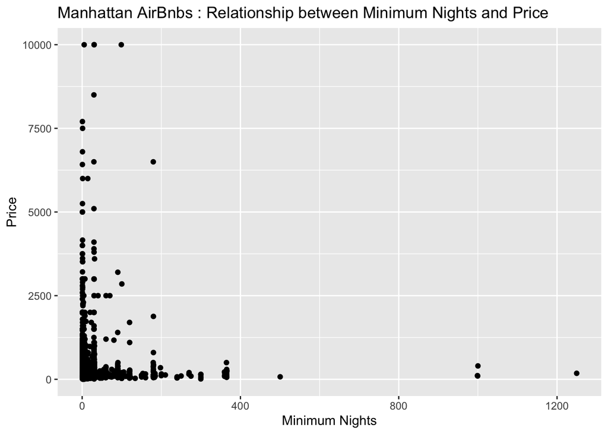

```r
  ggplot(manhattan, aes (x=minimum_nights, y = price)) + geom_jitter() +
 xlab ("Minimum Nights") + ylab ("Price") + ggtitle("Manhattan AirBnbs : Relationship between Minimum Nights and Price")
```

From the Jitter Plot, we see that minimum nights and price are negatively correlated. In other words, it appears that prices increases and minimum nights decreases.

People who want to rent our their space as an AirBnb rental would likely prefer not to have someone stay for a small amount of time, because that requires more work to find another renter. It is much easier to have someone stay a longer amount of time. The preference and goal of having renters stay longer amount of time is likely why the price goes down as the minimum nights required goes up.

## Does the length of the description have an impact of the rental price?

```r
description <-
manhattan %>%
summarize (name, price) %>%
mutate ( letter_count = str_length (name))
head (description)
```

```
## # A tibble: 6 x 3
## # Groups:   name [1]
##   name  price letter_count
##   <fct> <int>        <int>
## 1 ""      400            0
## 2 ""      200            0
## 3 ""      225            0
## 4 ""      215            0
## 5 ""       40            0
## 6 ""      190            0
```

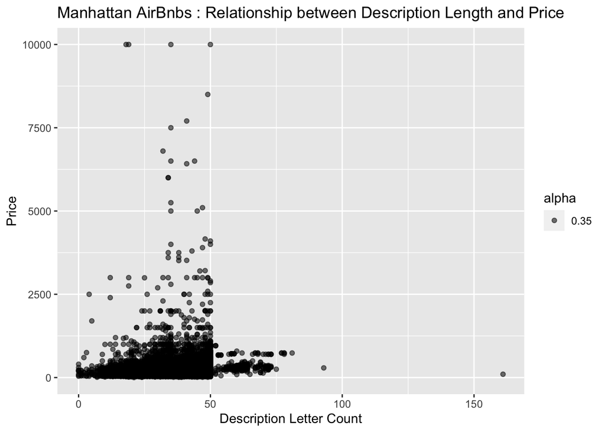

```r
#plot of correlation of description length and price
description %>%
ggplot(aes(x = letter_count, y = price, alpha = .35)) + geom_point() +
xlab ("Description Letter Count") + ylab ("Price") + ggtitle("Manhattan AirBnbs : Relationship between Description Length and Price")
```

## Impact of description on price

```r
#average price Manhattan AirBnbs
avg_price <- ( mean ( description$price))
avg_price
```

```
## [1] 196.8758
```

```r
#average price Manhattan AirBnbs with certain words in Description
cozy <-
    manhattan %>%
    filter ( grepl ( "Cozy", name, ignore.case = TRUE))

townhome <-
    manhattan %>%
    filter ( grepl ( "Townhome", name, ignore.case = TRUE))

tribeca <-
    manhattan %>%
    filter ( grepl ( "Tribeca", name, ignore.case = TRUE))

#average price Manhattan AirBnbs with Cozy in description
avg_price_cozy <- ( mean ( cozy$price))
avg_price_cozy
```

```
## [1] 129.6472
```

```r
#average price Manhattan AirBnbs with Townhome in description
avg_price_townhome <- ( mean ( townhome$price))
avg_price_townhome
```

```
## [1] 773.2308
```

```r
#average price Manhattan AirBnbs with Tribeca in description
avg_price_tribeca <- ( mean ( tribeca$price))
avg_price_tribeca
```

```
## [1] 441.4261
```

The average price for a Manhattan AirBnb rental is about $196.

The average price for a Manhattan AirBnb rental with the word “Cozy” in the description is about $130.

The average price for a Manhattan AirBnb rental with the word “Townhome” in the description is about $773.

The average price for a Manhattan AirBnb rental with the word “Tribeca” in the description is about $441.

We can also see that rentals with either “Townhome” or “Tribeca” in their description have a much higher average price than the average AirBnb rental. We can conclude that it is likely that these two keywords impact the rental price.

“Townhome” and “Tribeca” are both words that are typically correlated to more expensive rentals. “Townhome” suggests that the rental is probably a larger size than a typical NYC apartment. “Tribeca” suggests that the rental is located in the Tribeca area in NYC, which is a very wealthy and expensive area. This is likely while these keywords are correlated to higher rental prices.